# Decisión Multicriterio: Compra de un ordenador portátil

Alicia Casaux Vazquez

Curso 2024/25

# ENUNCIADO 1

Un usuario está considerando comprar un nuevo ordenador portátil para mejorar la productividad en su trabajo, se encuentra entre cinco diferentes modelos (*Dell XPS*, *HP Spectre*, *Lenovo ThinkPad*, *MacBook Air* y *Asus ZenBook*). Para elegir el mejor modelo se va estudiar una serie de criterios: **precio**, **rendimiento**, **duración de batería**, **peso/portabilidad**, **pantalla, durabilidad** y **conectividad/compatibilidad**.

- **Matriz de Criterios**

|  | Precio | Rendimiento | Duración de batería | Peso/Portabilidad | Pantalla | Durabilidad | Conectividad/Compatibilidad |
| --- | --- | --- | --- | --- | --- | --- | --- |
| Precio | 1.00 | 5.00 | 7.00 | 0.33 | 3.00 | 9.00 | 0.20 |
| Rendimiento | 0.20 | 1.00 | 0.33 | 5.00 | 0.11 | 7.00 | 3.00 |
| Duración de batería | 0.14 | 3.00 | 1.00 | 0.14 | 3.00 | 0.33 | 9.00 |
| Peso/Portabilidad | 3.00 | 0.20 | 7.00 | 1.00 | 3.00 | 0.11 | 0.20 |
| Pantalla | 0.33 | 9.00 | 0.33 | 0.33 | 1.00 | 9.00 | 0.14 |
| Durabilidad | 0.11 | 0.14 | 3.00 | 9.00 | 0.11 | 1.00 | 0.11 |
| Conectividad/Compatibilidad | 5.00 | 0.33 | 0.11 | 5.00 | 7.00 | 9.00 | 1.00 |

- **Matrices Alternativas/Criterios**
- *Precio*

|  | Dell XPS | HP Spectre | Lenovo ThinkPad | MacBook Air | Asus ZenBook |
| --- | --- | --- | --- | --- | --- |
| Dell XPS | 1.00 | 3 | 0.33 | 5.00 | 0.20 |
| HP Spectre | 0.33 | 1 | 0.14 | 0.11 | 0.33 |
| Lenovo ThinkPad | 3.00 | 7 | 1.00 | 5.00 | 9.00 |
| MacBook Air | 0.20 | 9 | 0.20 | 1.00 | 0.14 |
| Asus ZenBook | 5.00 | 3 | 0.11 | 7.00 | 1.00 |

- *Rendimiento*

  |  | Dell XPS | HP Spectre | Lenovo ThinkPad | MacBook Air | Asus ZenBook |
  | --- | --- | --- | --- | --- | --- |
  | Dell XPS | 1.00 | 0.2 | 7.00 | 0.33 | 9.00 |
  | HP Spectre | 5.00 | 1.0 | 0.11 | 0.14 | 5.00 |
  | Lenovo ThinkPad | 0.14 | 9.0 | 1.00 | 0.20 | 0.33 |
  | MacBook Air | 3.00 | 7.0 | 5.00 | 1.00 | 3.00 |
  | Asus ZenBook | 0.11 | 0.2 | 3.00 | 0.33 | 1.00 |

- *Duración de batería*

  |  | Dell XPS | HP Spectre | Lenovo ThinkPad | MacBook Air | Asus ZenBook |
  | --- | --- | --- | --- | --- | --- |
  | Dell XPS | 1.00 | 0.33 | 5.00 | 0.14 | 3.00 |
  | HP Spectre | 3.00 | 1.00 | 0.14 | 9.00 | 0.14 |
  | Lenovo ThinkPad | 0.20 | 7.00 | 1.00 | 3.00 | 5.00 |
  | MacBook Air | 7.00 | 0.11 | 0.33 | 1.00 | 7.00 |
  | Asus ZenBook | 0.33 | 7.00 | 0.20 | 0.14 | 1.00 |

- *Peso/Portabilidad*

  |  | Dell XPS | HP Spectre | Lenovo ThinkPad | MacBook Air | Asus ZenBook |
  | --- | --- | --- | --- | --- | --- |
  | Dell XPS | 1.00 | 9.0 | 5.0 | 0.33 | 0.14 |
  | HP Spectre | 0.11 | 1.0 | 0.2 | 0.33 | 5.00 |
  | Lenovo ThinkPad | 0.20 | 5.0 | 1.0 | 0.14 | 0.11 |
  | MacBook Air | 3.00 | 3.0 | 7.0 | 1.00 | 7.00 |
  | Asus ZenBook | 7.00 | 0.2 | 9.0 | 0.14 | 1.00 |

- *Pantalla*

  |  | Dell XPS | HP Spectre | Lenovo ThinkPad | MacBook Air | Asus ZenBook |
  | --- | --- | --- | --- | --- | --- |
  | Dell XPS | 1.00 | 3.00 | 0.14 | 0.11 | 5.00 |
  | HP Spectre | 0.33 | 1.00 | 0.33 | 3.00 | 5.00 |
  | Lenovo ThinkPad | 7.00 | 3.00 | 1.00 | 3.00 | 0.20 |
  | MacBook Air | 9.00 | 0.33 | 0.33 | 1.00 | 0.33 |
  | Asus ZenBook | 0.20 | 0.20 | 5.00 | 3.00 | 1.00 |

- *Durabilidad*

  |  | Dell XPS | HP Spectre | Lenovo ThinkPad | MacBook Air | Asus ZenBook |
  | --- | --- | --- | --- | --- | --- |
  | Dell XPS | 1.00 | 7.00 | 0.33 | 9.00 | 0.20 |
  | HP Spectre | 0.14 | 1.00 | 7.00 | 0.20 | 5.00 |
  | Lenovo ThinkPad | 3.00 | 0.14 | 1.00 | 3.00 | 0.33 |
  | MacBook Air | 0.11 | 5.00 | 0.33 | 1.00 | 3.00 |
  | Asus ZenBook | 5.00 | 0.20 | 3.00 | 0.33 | 1.00 |

- *Conectividad/Compatibilidad*

  |  | Dell XPS | HP Spectre | Lenovo ThinkPad | MacBook Air | Asus ZenBook |
  | --- | --- | --- | --- | --- | --- |
  | Dell XPS | 1.0 | 0.33 | 5.00 | 0.14 | 5.0 |
  | HP Spectre | 3.0 | 1.00 | 0.11 | 0.33 | 7.0 |
  | Lenovo ThinkPad | 0.2 | 9.00 | 1.00 | 3.00 | 0.2 |
  | MacBook Air | 7.0 | 3.00 | 0.33 | 1.00 | 9.0 |
  | Asus ZenBook | 0.2 | 0.14 | 5.00 | 0.11 | 1.0 |

# RESOLUCIÓN

## Funciones de clase

### Método 1 (mayor autovalor)

**Cálculo pesos locales**

*Método mayor autovalor*

```r
pes_criterios <- multicriterio.metodoAHP.variante1.autovectormayorautovalor(tabcriterios)
pes_precio <- multicriterio.metodoAHP.variante1.autovectormayorautovalor(tabprecio)
pes_rendimiento <- multicriterio.metodoAHP.variante1.autovectormayorautovalor(tabrendimiento)
pes_bateria <- multicriterio.metodoAHP.variante1.autovectormayorautovalor(tabbateria)
pes_peso <- multicriterio.metodoAHP.variante1.autovectormayorautovalor(tabpeso)
pes_pantalla <- multicriterio.metodoAHP.variante1.autovectormayorautovalor(tabpantalla)
pes_durabilidad <- multicriterio.metodoAHP.variante1.autovectormayorautovalor(tabdurabilidad)
pes_conect <- multicriterio.metodoAHP.variante1.autovectormayorautovalor(tabconect)
```

**Cálculo pesos globales**

```r
tab01 <- multicriterio.metodoAHP.pesosglobales_entabla(pes_criterios$valoraciones.ahp,
                                                       rbind(pes_precio$valoraciones.ahp,
                                                             pes_rendimiento$valoraciones.ahp,
                                                             pes_bateria$valoraciones.ahp,
                                                             pes_peso$valoraciones.ahp,
                                                             pes_pantalla$valoraciones.ahp,
                                                             pes_durabilidad$valoraciones.ahp,
                                                             pes_conect$valoraciones.ahp))
```

|  | Precio | Rendimiento | Duración de batería | Peso/Portabilidad | Pantalla | Durabilidad | Conectividad/Compatibilidad | Ponderadores Globales |
| --- | --- | --- | --- | --- | --- | --- | --- | --- |
| Dell XPS | 0.1247640 | 0.2311258 | 0.1660866 | 0.1948741 | 0.1728407 | 0.2931415 | 0.1879125 | 0.1875950 |
| HP Spectre | 0.0346318 | 0.1747181 | 0.2170032 | 0.1403104 | 0.1835130 | 0.2023359 | 0.1556741 | 0.1518941 |
| Lenovo ThinkPad | 0.5286548 | 0.1837526 | 0.2612805 | 0.0862825 | 0.2524430 | 0.1440758 | 0.2339569 | 0.2604395 |
| MacBook Air | 0.0810638 | 0.3322035 | 0.2072235 | 0.3439416 | 0.1886192 | 0.1648073 | 0.2970108 | 0.2276300 |
| Asus ZenBook | 0.2308856 | 0.0782000 | 0.1484063 | 0.2345913 | 0.2025842 | 0.1956395 | 0.1254457 | 0.1724413 |
| Ponder.Criterios | 0.1795623 | 0.1189326 | 0.1546403 | 0.1234269 | 0.1268178 | 0.0979715 | 0.1986485 | NA |

En general, la mejor decisión es el **Lenovo ThinkPad** con un peso global del 26,04%

Por criterios;

- Para el precio la mejor alternativa es el **Lenovo ThinkPad**
- Para el rendimiento la mejor alternativa es el **MacBook Air**
- Para la duración de la batería la mejor alternativa es el **Lenovo ThinkPad**
- Para el peso la mejor alternativa es el **MacBook Air**
- Para la pantalla la mejor alternativa es el **Lenovo ThinkPad**
- Para el durabilidad la mejor alternativa es el **Dell XPS**
- Para la conectividad la mejor alternativa es el **MacBook Air**

Además del método de mayor autovalor, tambien tenemos:

*Método de media geométrica*

```r
pes_criterios <- multicriterio.metodoAHP.variante2.mediageometrica(tabcriterios)
pes_precio <- multicriterio.metodoAHP.variante2.mediageometrica(tabprecio)
pes_rendimiento <- multicriterio.metodoAHP.variante2.mediageometrica(tabrendimiento)
pes_bateria <- multicriterio.metodoAHP.variante2.mediageometrica(tabbateria)
pes_peso <- multicriterio.metodoAHP.variante2.mediageometrica(tabpeso)
pes_pantalla <- multicriterio.metodoAHP.variante2.mediageometrica(tabpantalla)
pes_durabilidad <- multicriterio.metodoAHP.variante2.mediageometrica(tabdurabilidad)
pes_conect <- multicriterio.metodoAHP.variante2.mediageometrica(tabconect)
```

*Método básico*

```r
pes_criterios <- multicriterio.metodoAHP.variante3.basico(tabcriterios)
pes_precio <- multicriterio.metodoAHP.variante3.basico(tabprecio)
pes_rendimiento <- multicriterio.metodoAHP.variante3.basico(tabrendimiento)
pes_bateria <- multicriterio.metodoAHP.variante3.basico(tabbateria)
pes_peso <- multicriterio.metodoAHP.variante3.basico(tabpeso)
pes_pantalla <- multicriterio.metodoAHP.variante3.basico(tabpantalla)
pes_durabilidad <- multicriterio.metodoAHP.variante3.basico(tabdurabilidad)
pes_conect <- multicriterio.metodoAHP.variante3.basico(tabconect)
```

### Método 2 (completo)

```r
num.alt = 5
num.crt = 7
Xarray_nivel2 = array (NA, dim=c(num.alt, num.alt, num.crt))
Xarray_nivel2[,,1] = tabprecio
Xarray_nivel2[,,2] = tabrendimiento
Xarray_nivel2[,,3] = tabbateria
Xarray_nivel2[,,4] = tabpeso
Xarray_nivel2[,,5] = tabpantalla
Xarray_nivel2[,,6] = tabdurabilidad
Xarray_nivel2[,,7] = tabconect
pg_com = multicriterio.metodoAHP.variante3.completo(tabcriterios,Xarray_nivel2)
tab_com <- pg_com$pesos.globales_entabla
```

|  | Precio | Rendimiento | Duración de batería | Peso/Portabilidad | Pantalla | Durabilidad | Conectividad/Compatibilidad | Ponderadores Globales |
| --- | --- | --- | --- | --- | --- | --- | --- | --- |
|  | 0.1433275 | 0.2421649 | 0.2107623 | 0.1979299 | 0.1841517 | 0.2694524 | 0.1611429 | 0.1923483 |
|  | 0.0391459 | 0.1896988 | 0.2065061 | 0.1243509 | 0.1861870 | 0.2459275 | 0.1470103 | 0.1533816 |
|  | 0.4595213 | 0.1424911 | 0.2311811 | 0.0838012 | 0.2516734 | 0.1354492 | 0.2871511 | 0.2468869 |
|  | 0.1185559 | 0.3396191 | 0.2345913 | 0.3571430 | 0.1468619 | 0.1607775 | 0.2978349 | 0.2380975 |
|  | 0.2394493 | 0.0860260 | 0.1169592 | 0.2367750 | 0.2311259 | 0.1883933 | 0.1068609 | 0.1692858 |
| Ponder.Criterios | 0.1716361 | 0.1079521 | 0.1540136 | 0.1328629 | 0.1245957 | 0.0934374 | 0.2155021 | NA |

## Diagrama Jerarquías

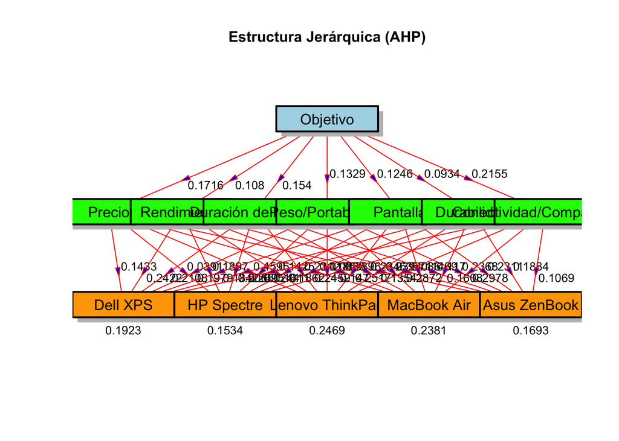

## Método AHP

[interactive chart not shown]

**Tabla solución (contribución total)**

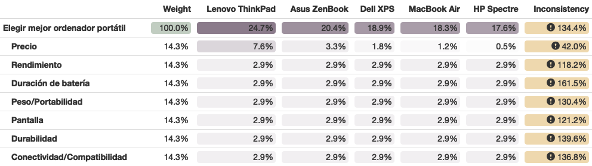

**Tabla solución (pesos locales)**

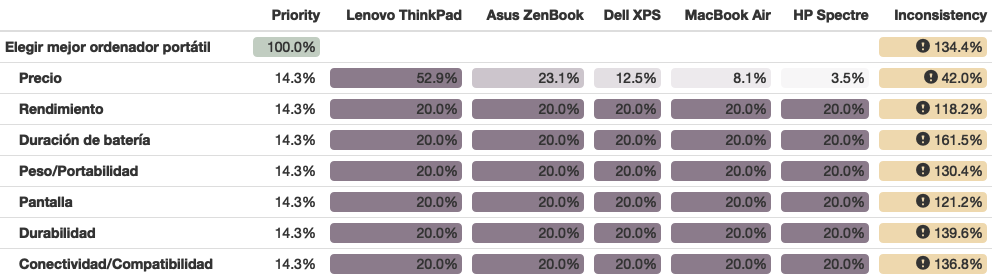